# Utilisation SVM pour analyse de données

Mme BADEL Anne

Eric

4 Juin 2019

But de l’étude:

On souhaite établir un modèle de prédiction de la clairance à partir de descripteurs géométrique et physico-chimiques de petits composés. Nous allons utiliser la méthode SVM pour répondre à la question.

## Preparation du jeu de données

Présentation des données

```
    CI ast_fraglike ast_fraglike_ext ast_violation
1 0.47            0                0             1
2 0.25            1                1             0
3 0.17            0                0             1
4 0.30            1                1             0
5 0.75            0                0             2
6 0.47            1                0             0
```

```
Nombre de descripteurs
                   208
```

```
Nombre de molecules (médicaments)
                               90
```

Normalisation des données

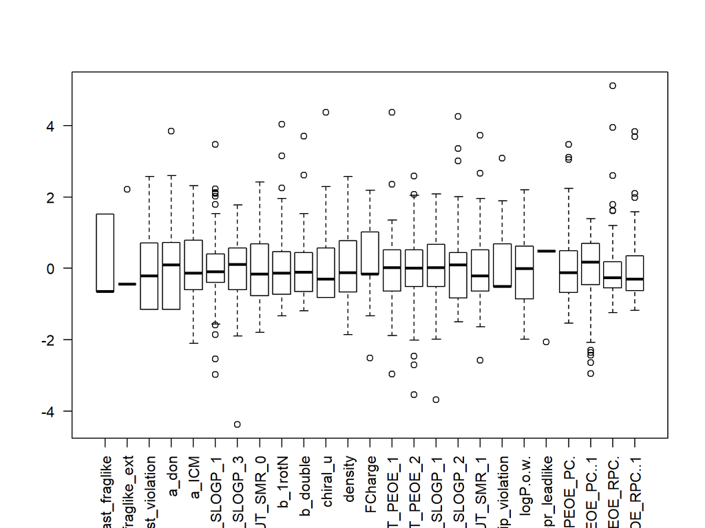

Visualisation des données grâce à une remise à l’échelle des donnée.(MDS)

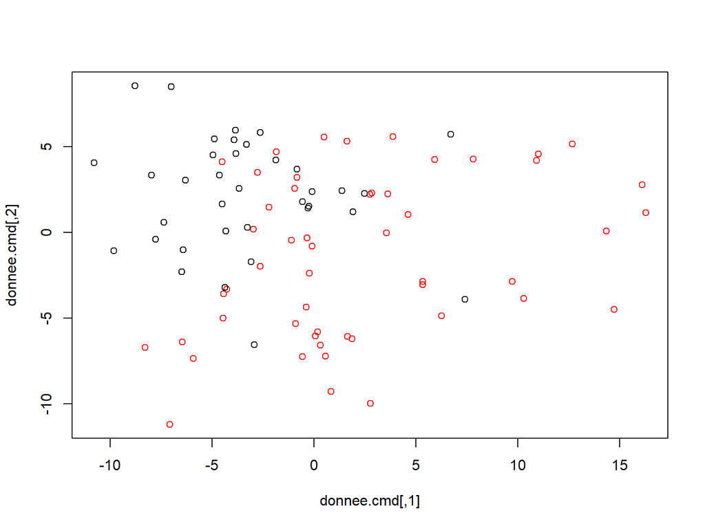

## Création des échantillons d’apprentissage et de test

Création d’un échantillon d’apprentissage

```
   ast_fraglike ast_fraglike_ext ast_violation       a_don
30    1.5190153        2.2236107    -1.1514964 -0.52779837
68   -0.6510065       -0.4447221     2.5830866  1.34727479
11   -0.6510065       -0.4447221    -0.2178507  0.09722602
61   -0.6510065       -0.4447221    -0.2178507 -0.52779837
45   -0.6510065       -0.4447221    -0.2178507  0.09722602
6     1.5190153       -0.4447221    -1.1514964  0.09722602
```

```
individus dans échantillon d'apprentissage
                                        60
```

Création d’un échantillon de validation (test)

```
   ast_fraglike ast_fraglike_ext ast_violation       a_don
1    -0.6510065       -0.4447221    -0.2178507  0.72225040
4     1.5190153        2.2236107    -1.1514964 -1.15282275
9    -0.6510065       -0.4447221     0.7157951  0.72225040
10    1.5190153       -0.4447221    -1.1514964  0.09722602
13   -0.6510065       -0.4447221     0.7157951  0.09722602
14   -0.6510065       -0.4447221     0.7157951  0.72225040
```

```
individus dans l'échantillon test
                               30
```

Verification de la répartition des individus dans nos échantillons (test d’homogénéité)

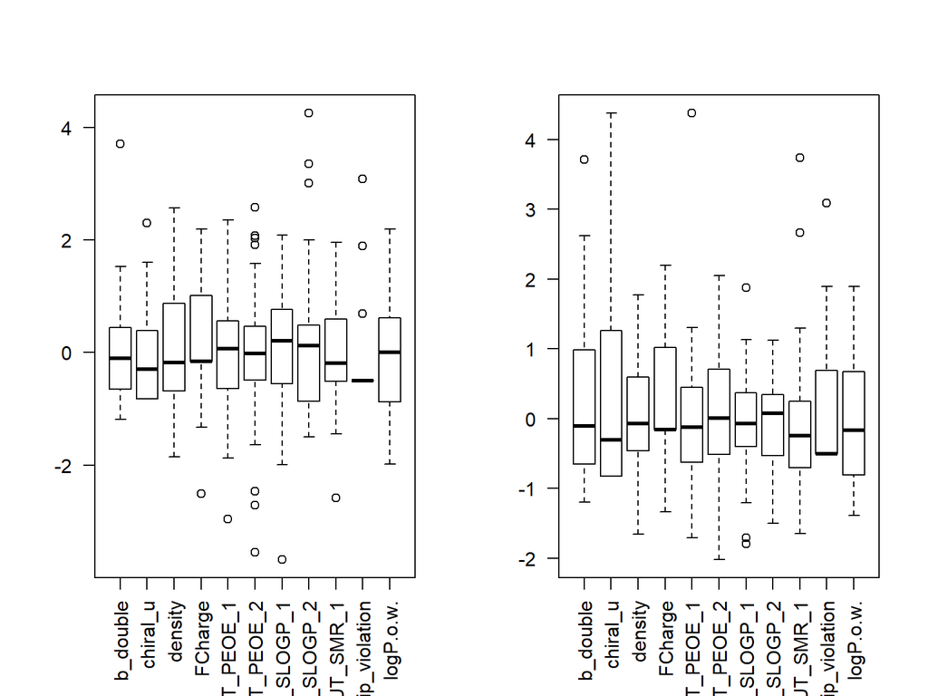

**Une méthode de prédiction : support vector machines (SVM)**

- Technique de classification et de régréssion des données
- Permet la classification de plusieurs données à la fois (OvA ET OvO)
- Se base sur 2 idées clés : la notion de *marge maximale* et la notion du *noyau* (kernel)

**La marge maximale**

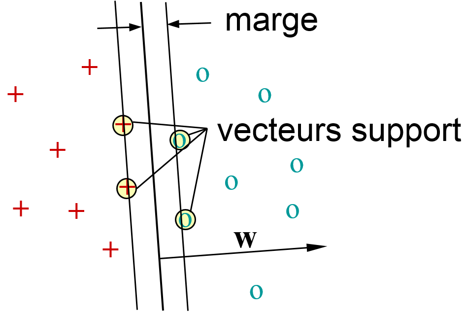

**Le kernel**

- Ensemble de fonctions mathématique ayant pour but de repésenter les données sous une forme particulière
- Plusieurs types de kernel : **Linéaire, polynomial, radial et sigmoïde**
- *Kernel trick*

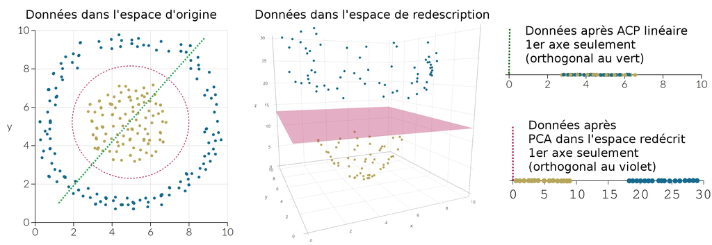

Résultats des prédictions avec différents noyaux (kernel)

[figure not shown]

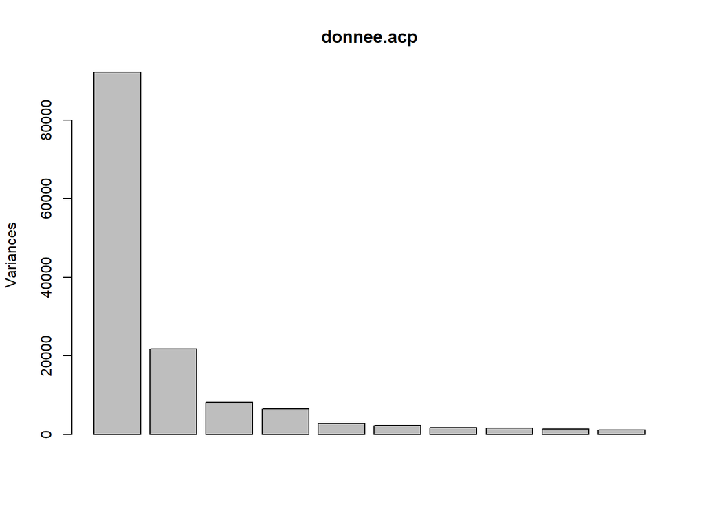